# Source Aggregation

Andrew L Jackson

13 March, 2025

## Create some simulated data for us to work with

This is essentially the example used in Fry, B. 2013. Alternative approaches for solving under-determined isotope mixing problems. *MEPS*.

Here we use the package `simmr` to explore the two alternatives to aggregating sources in mixing models.

```r
library(simmr, quietly = TRUE)

# Set the random seed so we get the same set of
# random numbers each time we run this example.
set.seed(1)

# specify the sources
# sources <- data.frame(sources=c("A","B","C","D"),
#                         muC=c(-5,-5,5,5),sdC=c(1,1,1,1),
#                         muN=c(-5,5,5,-5),sdN=c(1,1,1,1))

# specify the source names
S_names = c("A","B","C","D")

# specify the source means by binding two vectors
# together into a matrix by columns.
S_means = cbind(c(-5,-5,5,5), c(-5,5,5,-5))

# specify the source standard deviations
S_sds = cbind(c(1,1,1,1), c(1,1,1,1))

# specify the consumer data at the origin
# Ten consumers for this example around 0 with small sd of error.
consumers <- cbind(dC = rnorm(n = 10, mean = 0, sd = 0.1),
                   dN = rnorm(n = 10, mean = 0, sd = 0.1) )

# and create the simmr object
# here we have no TDFs or concentration values
simmr_in <- simmr_load(mixtures = consumers,
                       source_names = S_names,
                       source_means = S_means,
                       source_sds = S_sds)
```

Now we can plot the data to visualise our system and the output,

```r
plot(simmr_in)
```

[output not shown]

## Fit the SIMM

We can fit a simmr model using the defaults, and here suppress the output using the `results='hide'` option in the chunk.

```r
simmr_out = simmr_mcmc(simmr_in)
```

And we should always check for convergence.

```r
# a summary table of convergence diagnostics
summary(simmr_out,type='diagnostics')
```

```
Summary for 1

R-hat values - these values should all be close to 1.

If not, try a longer run of simmr_mcmc.
```

```
deviance        A        B        C        D   sd[dC]   sd[dN]
    1.00     1.01     1.01     1.01     1.01     1.00     1.00
```

[output not shown]

[output cut: 16 more lines]

[output not shown]

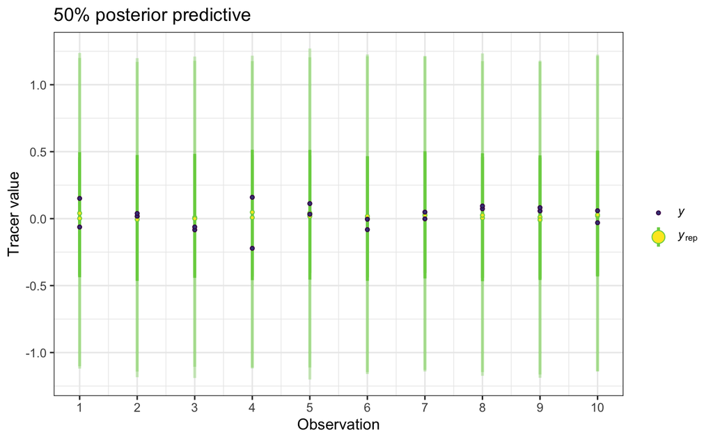

```r
# plot the posterior predictive power
posterior_predictive(simmr_out)
```

The results of this toy example are not expected to be overly helpful or meaningful.

```r
summary(simmr_out,type='statistics')
```

```
Summary for 1
```

```
           mean    sd
deviance 22.528 6.039
A         0.245 0.075
B         0.254 0.076
C         0.249 0.076
D         0.252 0.075
sd[dC]    0.390 0.223
sd[dN]    0.402 0.226
```

```r
summary(simmr_out,type='quantiles')
```

```
Summary for 1
```

```
           2.5%    25%    50%    75%  97.5%
deviance 13.503 18.102 21.602 26.032 36.361
A         0.097  0.193  0.244  0.299  0.392
B         0.105  0.202  0.255  0.307  0.404
C         0.103  0.197  0.248  0.300  0.400
D         0.106  0.200  0.254  0.303  0.399
sd[dC]    0.097  0.236  0.348  0.494  0.912
sd[dN]    0.098  0.243  0.357  0.507  0.960
```

Plot the estimates of the dietary proportions

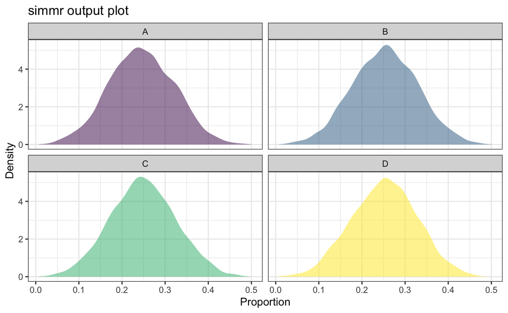

```r
# Plot the a priori aggregated diet estimatess
plot(simmr_out, type = "density")
```

Plot the covariance between the estimated dietary proportions in the posterior.

[figure not shown]

```r
plot(simmr_out, type = "matrix")
```

## *A priori* aggregation

We combine the sources C and D before we run the model as is sometimes suggested. We do this by taking the mean of the means, and we square the SDs to make them variances, then add them, and then square-root them to turn them back into SDs again. We dont need to change the consumer data in any way.

```r
# specify the source names
S_names_a_priori = c("A","B","CD")

# take the mean of the last two sources C and D
S_means_a_priori = rbind(S_means[1:2,],
                         colMeans(S_means[3:4,]) )

# square the sds for sources C and D to convert to variance,
# sum them and convert back to sd
S_sds_a_priori = rbind( S_sds[1:2,], colSums(S_sds[3:4,]^2) ^ 0.5 )

# and create the new simmr object
# here we have no TDFs or concentration values
simmr_in_a_priori <- simmr_load(mixtures = consumers,
                       source_names = S_names_a_priori,
                       source_means = S_means_a_priori,
                       source_sds = S_sds_a_priori)
```

Plot this newly combined data.

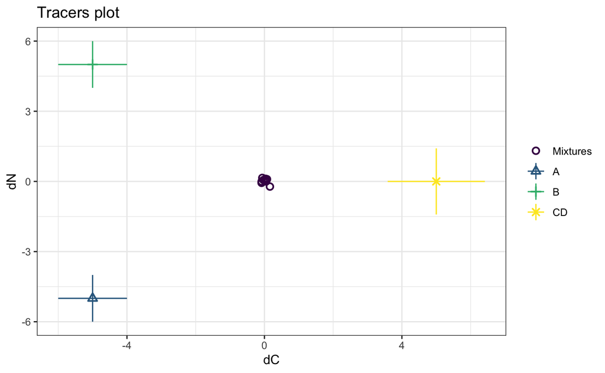

```r
# plot the raw data for the a priori aggregated example
plot(simmr_in_a_priori)
```

Run the model on the a priori combined data.

```r
# fit the a priori aggregated models
simmr_out_a_priori = simmr_mcmc(simmr_in_a_priori)
```

[output not shown]

[output cut: 16 more lines]

[output not shown]

And plot

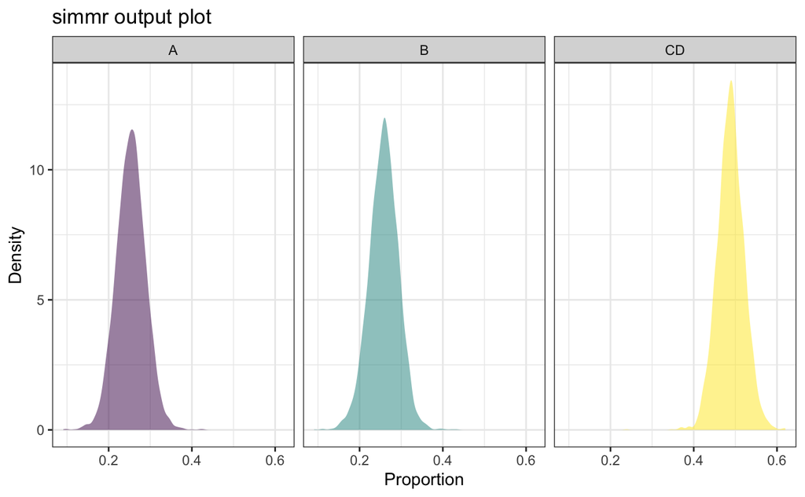

```r
# Plot the a priori aggregated diet estimatess
plot(simmr_out_a_priori, type = "density")
```

[figure not shown]

```r
plot(simmr_out_a_priori, type = "matrix")
```